# Лабораторная работа № 8

Поиск файлов. Перенаправление ввода-вывода. Просмотр запущенных процессов

Чжан Вэньцзюнь

Российский университет дружбы народов

2026-10-20

# Информация

## Докладчик

- Чжан Вэньцзюнь
- зачётная книжка № 1132259051
- Российский университет дружбы народов им. П. Лумумбы

## Цель работы

- Ознакомление с инструментами поиска файлов и фильтрации текстовых данных
- Управление процессами и задачами
- Проверка использования диска и обслуживание файловых систем

## Задание

1. Записать в `file.txt` имена файлов `/etc` и домашнего каталога
2. Отобрать файлы с расширением `.conf` в `conf.txt`
3. Найти файлы, начинающиеся с `c`
4. Вывести имена файлов `/etc`, начинающиеся с `h`
5. Запустить фоновый поиск с записью в `~/logfile`
6. Запустить `gedit`, найти его PID и завершить процесс
7. Выполнить `df` и `du`, вывести каталоги домашнего каталога

# Выполнение работы

## Перенаправление потоков

```bash
ls /etc > file.txt        # перезапись
ls ~ >> file.txt          # добавление
wc -l file.txt            # 296 строк
grep '\.conf$' file.txt > conf.txt   # 42 строки
```

| Операция | Действие |
| --- | --- |
| `>` | запись с перезаписью |
| `>>` | добавление в конец |
| `2>` | перенаправление stderr |
| `&>` | stdout и stderr вместе |

## Поиск файлов

```bash
find ~ -maxdepth 1 -name "c*"
ls ~ | grep '^c'
compgen -f -- ~/c
```

- Три способа дают одинаковый результат
- `find /etc -maxdepth 1 -name 'h*'` → `host.conf`, `hostname`, `hosts`, `hp`

## Фоновый режим и конвейер

```bash
find ~ -name 'log*' > ~/logfile &   # фон
cat ~/logfile
rm ~/logfile
```

- `&` запускает команду в фоне, консоль свободна
- конвейер `|` передаёт stdout первой команды на stdin второй

## Управление задачами

```bash
sleep 300 &
sleep 400 &
jobs
# [1]-  Запущен  sleep 300 &
# [2]+  Запущен  sleep 400 &
kill %1 %2
```

## Процессы и PID

```bash
gedit ~/gedit-demo.txt &
ps -C gedit -o pid,user,comm,args
# 20021 vzhang gedit gedit /home/vzhang/gedit-demo.txt
pgrep -x gedit         # 20021
kill 20021
ps -C gedit -o pid,comm || echo "процесс gedit завершён"
```

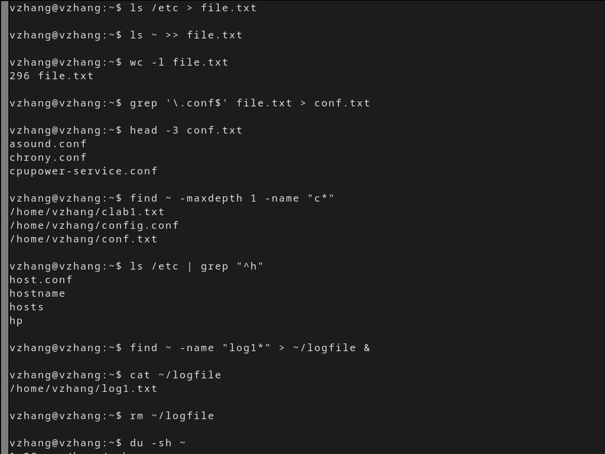

Поиск файлов и перенаправление ввода-вывода

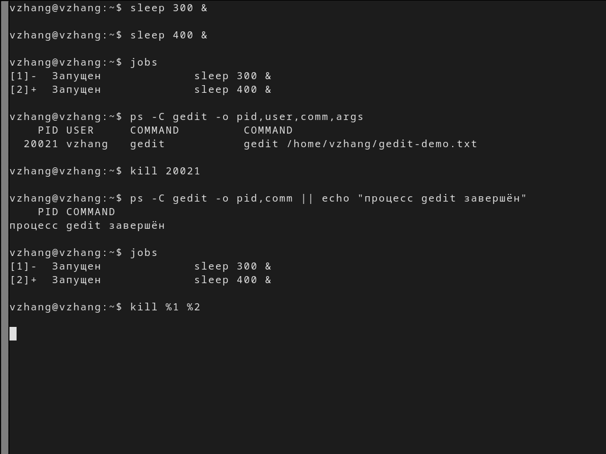

Управление задачами и процессами

## Проверка диска

```bash
df -h | head -5
du -sh ~
```

- `/dev/dm-0` — 38G, занято 12%
- домашний каталог — 1,2G
- `du -h --max-depth=1 ~` — по подкаталогам

## Каталоги домашнего каталога

```bash
find ~ -maxdepth 1 -type d
```

- `-type d` — только каталоги
- `-maxdepth 1` — без вложенных уровней

# Заключение

## Спасибо за внимание!

Вопросы?